# 蒙特卡洛方法

王宁宁

## 蒙特卡洛方法

很多时候，我们需要计算积分，但是大多数情形下的积分很难给出解析解，我们可以通过蒙特卡洛方法给出数值模拟解。

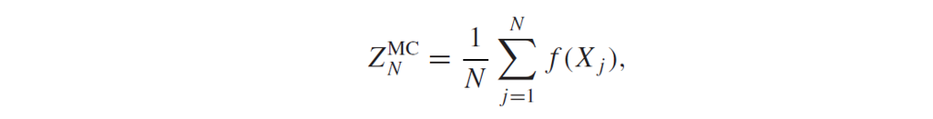

### 1、蒙特卡洛原理

通常形式的任一个积分都可以表示成某个随机变量期望的形式：

$\int_0^1 f(t)dt= E (f(U))$

思考：

a）、如果是$\int _a ^b f(t)dt$怎么表示成某个随机变量的期望？

b）、任一个概率怎么表示成某个随机变量的期望？

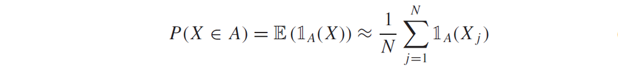

根据（强）大数定律：

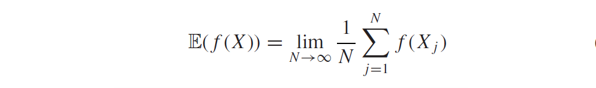

所以理论上只要能够得到Ｘ的随机数，就可以逼近想要的积分。

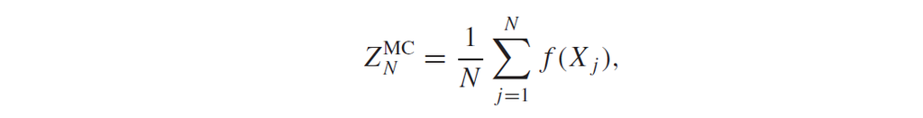

### 2、模拟次数

如何根据精度选择模拟的次数？

无偏性：

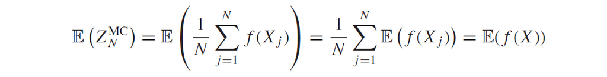

由于X是独立的：

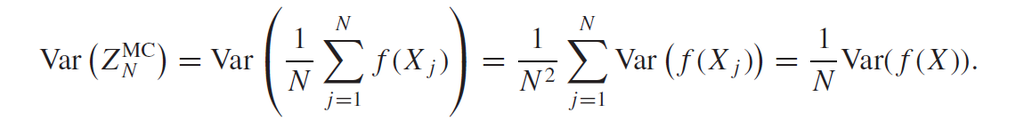

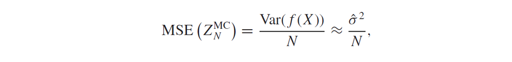

其中

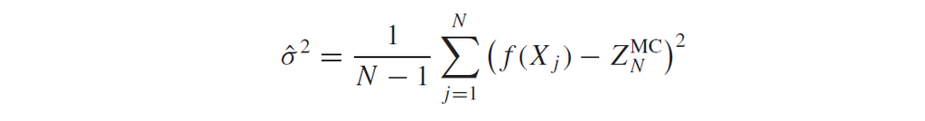

可以这样估计次数：

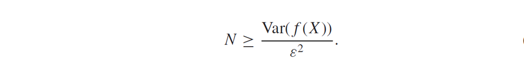

### MSE

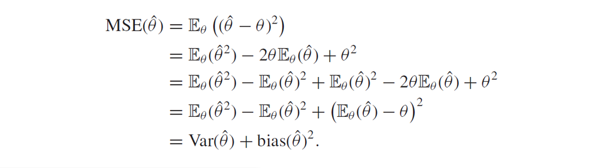

## **MC算法**的例子

### 例1

1、假定X来自Exp(1), 而Y|X来自N(0,X), 现在已知Y=4，利用MC方法求E(X|Y=4)以及Var(X|Y=4) （从后验分布里抽取10000份样本，计算样本均数和样本方差）。

贝叶斯公式：

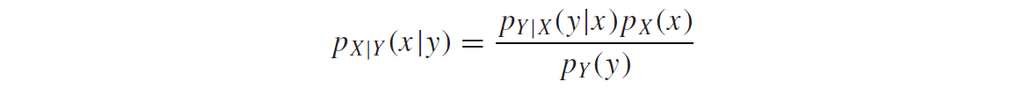

已知：

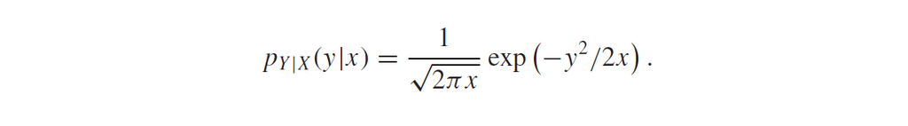

故：

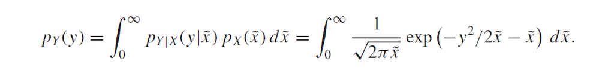

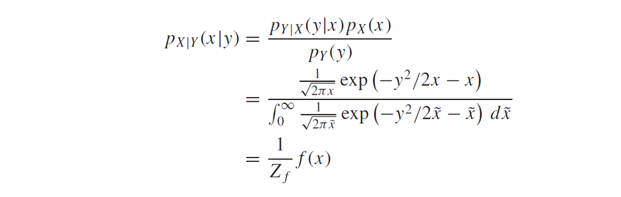

其中：

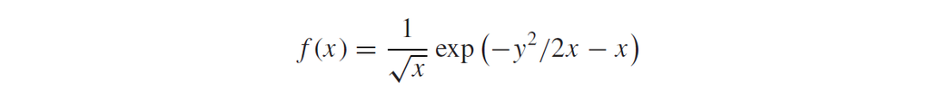

使用筛法对上述f(x)抽样，选取：

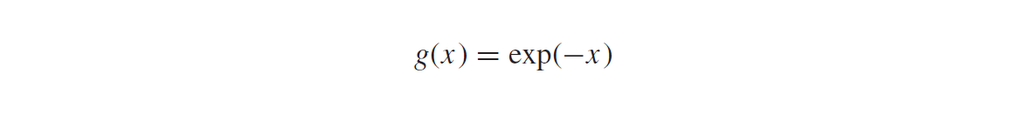

以及：

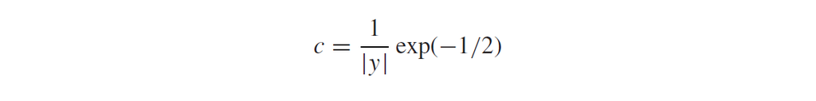

故：

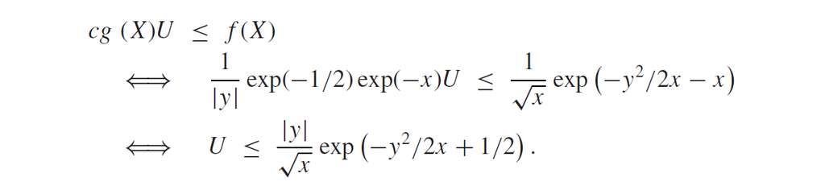

抽样算法：

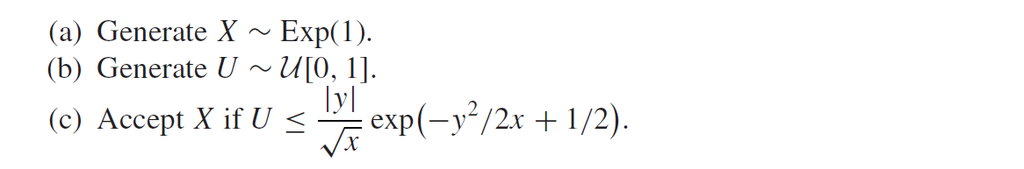

```r
GeneratePosteriorSamples <- function(n, y) {
  res <- c()
  while (length(res) < n) {
      X <- rexp(1)
      U <- runif(1)
      if (U <= abs(y) * exp(-y^2/(2*X) + 0.5) / sqrt(X)) {
        res <- c(res, X)
      }
  }
  return(res)
};
X <- GeneratePosteriorSamples(10000, 4)
mean(X)
```

```
## [1] 3.347783
```

```r
var(X)
```

```
## [1] 2.021675
```

**MC算法的精度**

### 例2

2、假定X来自N(0,1), 利用MC算法估计$E(\sin(x)^2)$，具体如下：

1）、抽样1000000次，算出均值。

2）、每次抽样1000次，算出一个均值，重复10000次，画出这10000个均值的直方图。

3）、每次抽样10000次，算出一个均值，重复10000次，画出这10000个均值的直方图。

```r
GetMCEstimate <- function(N) {
  X <- rnorm(N)
  return(mean(sin(X)^2))
}
GetMCEstimate(1000000)
```

```
## [1] 0.4326773
```

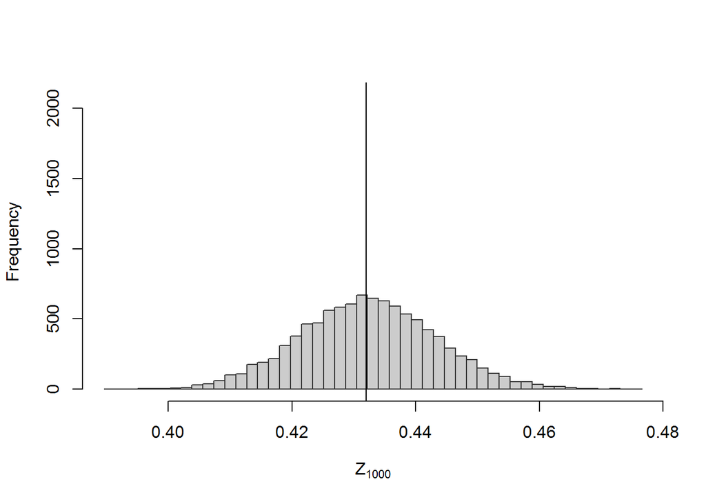

```r
estimates <- replicate(10000, GetMCEstimate(1000))
range <- c(min(estimates), max(estimates))
hist(estimates, breaks=seq(range[1], range[2], length.out=50),xlab=expression(Z[1000]), xlim=range, ylim=c(0,2100),main=NULL, col="gray80", border="gray20")


good.estimate <- GetMCEstimate(1000000)
abline(v=good.estimate)
```

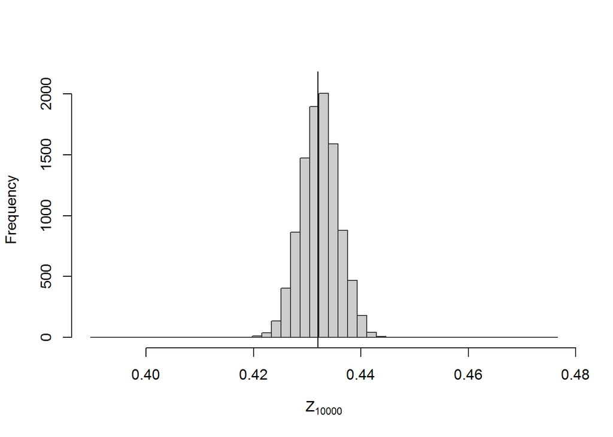

```r
estimates2 <- replicate(10000, GetMCEstimate(10000))
hist(estimates2, breaks=seq(range[1], range[2], length.out=50),xlab=expression(Z[10000]), xlim=range, ylim=c(0,2100),main=NULL, col="gray80", border="gray20")
abline(v=good.estimate)
```

### 例3

3、已知假定X来自N(0,1), 利用MC算法估计$E(\cos(x))$，如果需要3位有效数字，至少需要抽样多少次？（确定数量级即可）

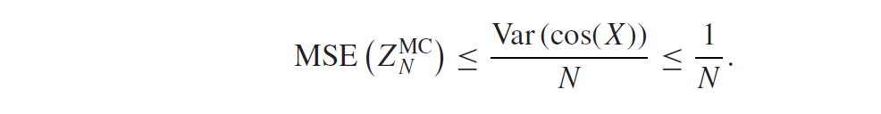

根据：

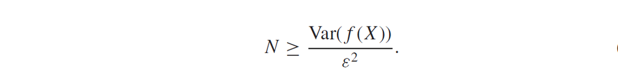

需要$10^6$抽样

```r
N <- 1e6
X <- rnorm(N)
mean(cos(X))
```

```
## [1] 0.6063973
```

```r
var(cos(X))
```

```
## [1] 0.1998028
```